# IMT 573 - Final Examination

Points: 100

Name: Jaspreet Bhamipuri

### Instructions

This is a take-home final examination. You may use your computer, books/articles, notes, course materials, etc., but all work must be your own! Please review the course policy on AI-based learning tools. References must be appropriately cited. Please justify your answers and show all work; a complete argument must be presented to obtain full credit. Before beginning this exam, please ensure you have access to data programming environments used in the course; this can be on your own personal computer or on shared infrastructure hosted by the university.

1. Download the exam template notebook file from Canvas. Open exam notebook and supply your solutions to the exam by editing the notebook.
2. Be sure the exam contains your full name.
3. Be sure to include well-documented (e.g. commented) code chucks, figures, and clearly written text chunk explanations as necessary. Any figures should be clearly labeled and appropriately referenced within the text. Be sure that each visualization adds value to your written explanation; avoid redundancy -- you do not need four different visualizations of the same pattern.
4. **Collaboration is not allowed on this exam. You may only speak with the course instructor about this material.**
5. All materials and resources that you use (with the exception of lecture slides) must be appropriately referenced within your assignment.
6. Remember partial credit will be awarded for each question for which a serious attempt at finding an answer has been shown. Students are **strongly** encouraged to attempt each question and to document their reasoning process even if they cannot find the correct answer. If you would like to include code to show this process, but it does not run without errors, you can do so by commenting out that code.
7. When you have completed the assignment and have **checked** that your code both runs in the Console and compiles correctly rename the file to `YourLastName_YourFirstName.ipynb`, and submit BOTH your HTML and notebook files on Canvas.

### Statement of Compliance

You **must** include the a "signed" Statement of Compliance in your submission. The Compliance Statement is found below. You must include this text, word-for-word, in your final exam submission. Adding your name indicates you have read the statement and agree to its terms. Failure to do so will result in your exam **not** being accepted.

**Statement of Compliance**

I affirm that I have had no conversation regarding this exam with any persons other than the instructor. Further, I certify that the attached work represents my own thinking. Any information, concepts, or words that originate from other sources are cited in accordance with University of Washington guidelines as published in the Academic Code (available on the course website). I am aware of the serious consequences that result from improper discussions with others or from the improper citation of work that is not my own.

(you name goes here as signature) : Jaspreet Bhamipuri

(date of signature) : 11/25/2025

For this assignment, you'll need (at least) the following packages. If the package does not load, be sure it is properly installed.

```python
import pandas as pd
import numpy as np
import matplotlib.pyplot as plt
import seaborn as sns
import statsmodels.api as sm
```

### Problem 1

Points: 20

In this problem we will use data on infidelity, known as the Fair's Affairs dataset. The `Affairs` dataset is available as part of the `datasets` package in`statsmodels`. This data comes from a survey conducted by Psychology Today in 1969, see Greene (2003) and Fair (1978) for more information.

The dataset contains various self-reported characteristics of 6366 participants, including how often the respondent engaged in extramarital sexual intercourse during the past year, as well as their gender, age, year married, whether they had children, their religiousness (on a 5-point scale, from 1=anti to 5=very), education, occupation (Hillingshead 7-point classification with reverse numbering), and a numeric self-rating of their marriage (from 1=very unhappy to 5=very happy).

(a) Describe the participants. Use descriptive, summarization, and exploratory techniques to describe the participants in the study. Tell us the average/mean of children count ? What is the average age of respondents? In your response comment on any ethical and privacy concerns you have with this dataset.

```python
affairs = sm.datasets.fair.load_pandas().data
print(sm.datasets.fair.NOTE)
```

```
::

    Number of observations: 6366
    Number of variables: 9
    Variable name definitions:

        rate_marriage   : How rate marriage, 1 = very poor, 2 = poor, 3 = fair,
                        4 = good, 5 = very good
        age             : Age
        yrs_married     : No. years married. Interval approximations. See
                        original paper for detailed explanation.
        children        : No. children
        religious       : How relgious, 1 = not, 2 = mildly, 3 = fairly,
                        4 = strongly
        educ            : Level of education, 9 = grade school, 12 = high
                        school, 14 = some college, 16 = college graduate,
                        17 = some graduate school, 20 = advanced degree
        occupation      : 1 = student, 2 = farming, agriculture; semi-skilled,
                        or unskilled worker; 3 = white-colloar; 4 = teacher
                        counselor social worker, nurse; artist, writers;
                        technician, skilled worker, 5 = managerial,
                        administrative, business, 6 = professional with
                        advanced degree
        occupation_husb : Husband's occupation. Same as occupation.
        affairs         : measure of time spent in extramarital affairs

    See the original paper for more details.
```

```python
affairs.head()
```

|  | rate_marriage | age | yrs_married | children | religious | educ | occupation | occupation_husb | affairs |
| --- | --- | --- | --- | --- | --- | --- | --- | --- | --- |
| 0 | 3.0 | 32.0 | 9.0 | 3.0 | 3.0 | 17.0 | 2.0 | 5.0 | 0.111111 |
| 1 | 3.0 | 27.0 | 13.0 | 3.0 | 1.0 | 14.0 | 3.0 | 4.0 | 3.230769 |
| 2 | 4.0 | 22.0 | 2.5 | 0.0 | 1.0 | 16.0 | 3.0 | 5.0 | 1.400000 |
| 3 | 4.0 | 37.0 | 16.5 | 4.0 | 3.0 | 16.0 | 5.0 | 5.0 | 0.727273 |
| 4 | 5.0 | 27.0 | 9.0 | 1.0 | 1.0 | 14.0 | 3.0 | 4.0 | 4.666666 |

```python
affairs.info()
affairs.describe()
```

```
<class 'pandas.core.frame.DataFrame'>
RangeIndex: 6366 entries, 0 to 6365
Data columns (total 9 columns):
 #   Column           Non-Null Count  Dtype
---  ------           --------------  -----
 0   rate_marriage    6366 non-null   float64
 1   age              6366 non-null   float64
 2   yrs_married      6366 non-null   float64
 3   children         6366 non-null   float64
 4   religious        6366 non-null   float64
 5   educ             6366 non-null   float64
 6   occupation       6366 non-null   float64
 7   occupation_husb  6366 non-null   float64
 8   affairs          6366 non-null   float64
dtypes: float64(9)
memory usage: 447.7 KB
```

|  | rate_marriage | age | yrs_married | children | religious | educ | occupation | occupation_husb | affairs |
| --- | --- | --- | --- | --- | --- | --- | --- | --- | --- |
| count | 6366.000000 | 6366.000000 | 6366.000000 | 6366.000000 | 6366.000000 | 6366.000000 | 6366.000000 | 6366.000000 | 6366.000000 |
| mean | 4.109645 | 29.082862 | 9.009425 | 1.396874 | 2.426170 | 14.209865 | 3.424128 | 3.850141 | 0.705374 |
| std | 0.961430 | 6.847882 | 7.280120 | 1.433471 | 0.878369 | 2.178003 | 0.942399 | 1.346435 | 2.203374 |
| min | 1.000000 | 17.500000 | 0.500000 | 0.000000 | 1.000000 | 9.000000 | 1.000000 | 1.000000 | 0.000000 |
| 25% | 4.000000 | 22.000000 | 2.500000 | 0.000000 | 2.000000 | 12.000000 | 3.000000 | 3.000000 | 0.000000 |
| 50% | 4.000000 | 27.000000 | 6.000000 | 1.000000 | 2.000000 | 14.000000 | 3.000000 | 4.000000 | 0.000000 |
| 75% | 5.000000 | 32.000000 | 16.500000 | 2.000000 | 3.000000 | 16.000000 | 4.000000 | 5.000000 | 0.484848 |
| max | 5.000000 | 42.000000 | 23.000000 | 5.500000 | 4.000000 | 20.000000 | 6.000000 | 6.000000 | 57.599991 |

###### Describe the participants. Use descriptive, summarization, and exploratory techniques to describe the participants in the study.

```python
# Tell us the average/mean of children count?
children_count = affairs['children'].value_counts().drop(0)
print(children_count)
# I do not want to include the count of zero, to get accurate count avg
children_avg = (children_count).mean()
print('Average Children Count: ' + str(children_avg))
```

```
children
2.0    1481
1.0    1159
3.0     781
4.0     328
5.5     203
Name: count, dtype: int64
Average Children Count: 790.4
```

###### In your response comment on any ethical and privacy concerns you have with this dataset.

- I want to know how are these people categorized, and how accurate this information is.
- The children value count and max value for children is 5.5, does the 0.5 represent a baby?
- There seems to be assumptions made and listed.
  - How is privacy affected and it seems that correlation could be made?
- The information we have about is limited in determining such serious matters.
  - How was the affairs column created and how was privacy guaranteed?
- There seems to be only a column specfically for Husband ocupation and also labeled as such and there is no label for partner/wife occupation?

(b) Suppose we want to explore the characteristics of participants who engage in extramarital sexual intercourse (i.e. affairs). Instead of modeling the number of affairs, consider the binary outcome - had an affair versus didn't have an affair. Create a new variable to capture this response variable of interest. What might the advantages and disadvantages of this approach to modeling the data be in this context?

```python
# Create a new variable for the binary outcome - had an affair versus didn't have an affair
had_affair = affairs['affairs'] > 0
# If had an affair, assign value 1, else 0
affairs['had_affair'] = had_affair.astype(int)
# Test
affairs.head(10)
affairs['had_affair'].value_counts()
```

```
had_affair
0    4313
1    2053
Name: count, dtype: int64
```

###### What might the advantages and disadvantages of this approach to modeling the data be in this context?

- It makes the data a little easier to understand by making 'affair' vs 'no_affair'
- There could be limited or even lost data, like related to much time was spent during affair, about affair.

(c) Use an appropriate regression model to explore the relationship between having an affair (binary) and other personal characteristics. Comment on which covariates seem to be predictive of having an affair and which do not.

```python
# Regression Model & Referenced: Bhamipuri, J. (2025). IMT_573_ps7_regression.ipynb
X = affairs[['rate_marriage', 'age', 'yrs_married', 'children', 'religious', 'educ', 'occupation', 'occupation_husb']]
y = affairs['had_affair']

# Referenced: Bhamipuri, J. (2025). IMT_573_Lab7_regression.ipynb
X = sm.add_constant(X)
model = sm.OLS(y, X).fit()

print(model.summary())
```

```
                            OLS Regression Results
==============================================================================
Dep. Variable:             had_affair   R-squared:                       0.161
Model:                            OLS   Adj. R-squared:                  0.160
Method:                 Least Squares   F-statistic:                     152.3
Date:                Sun, 30 Nov 2025   Prob (F-statistic):          1.90e-235
Time:                        15:44:13   Log-Likelihood:                -3633.4
No. Observations:                6366   AIC:                             7285.
Df Residuals:                    6357   BIC:                             7346.
Df Model:                           8
Covariance Type:            nonrobust
===================================================================================
                      coef    std err          t      P>|t|      [0.025      0.975]
-----------------------------------------------------------------------------------
const               1.2063      0.053     22.692      0.000       1.102       1.310
rate_marriage      -0.1452      0.006    -25.557      0.000      -0.156      -0.134
age                -0.0109      0.002     -5.936      0.000      -0.014      -0.007
yrs_married         0.0207      0.002     10.490      0.000       0.017       0.025
children           -0.0021      0.006     -0.358      0.720      -0.014       0.010
religious          -0.0676      0.006    -10.850      0.000      -0.080      -0.055
educ               -0.0070      0.003     -2.496      0.013      -0.013      -0.002
occupation          0.0298      0.006      4.757      0.000       0.018       0.042
occupation_husb     0.0019      0.004      0.465      0.642      -0.006       0.010
==============================================================================
Omnibus:                     1215.296   Durbin-Watson:                   0.318
Prob(Omnibus):                  0.000   Jarque-Bera (JB):              613.311
Skew:                           0.612   Prob(JB):                    6.63e-134
Kurtosis:                       2.099   Cond. No.                         349.
==============================================================================

Notes:
[1] Standard Errors assume that the covariance matrix of the errors is correctly specified.
```

###### Comment on which covariates seem to be predictive of having an affair and which do not.

(d) Use a model selection procedure to obtain a "best" fit model. Is the model different from the full model you fit in part (c)? Which variables are included in the "best" fit model? [Hint: stepwise selection]

```python
# Referenced: Bhamipuri, J. (2025). IMT_573_ps7_logistic_regression.ipynb
X = sm.add_constant(X)
logit_model = sm.Logit(y, X).fit()

print(logit_model.summary())
```

```
Optimization terminated successfully.
         Current function value: 0.545314
         Iterations 6
                           Logit Regression Results
==============================================================================
Dep. Variable:             had_affair   No. Observations:                 6366
Model:                          Logit   Df Residuals:                     6357
Method:                           MLE   Df Model:                            8
Date:                Sun, 30 Nov 2025   Pseudo R-squ.:                  0.1327
Time:                        16:10:14   Log-Likelihood:                -3471.5
converged:                       True   LL-Null:                       -4002.5
Covariance Type:            nonrobust   LLR p-value:                5.807e-224
===================================================================================
                      coef    std err          z      P>|z|      [0.025      0.975]
-----------------------------------------------------------------------------------
const               3.7257      0.299     12.470      0.000       3.140       4.311
rate_marriage      -0.7161      0.031    -22.784      0.000      -0.778      -0.655
age                -0.0605      0.010     -5.885      0.000      -0.081      -0.040
yrs_married         0.1100      0.011     10.054      0.000       0.089       0.131
children           -0.0042      0.032     -0.134      0.893      -0.066       0.058
religious          -0.3752      0.035    -10.792      0.000      -0.443      -0.307
educ               -0.0392      0.015     -2.533      0.011      -0.070      -0.009
occupation          0.1602      0.034      4.717      0.000       0.094       0.227
occupation_husb     0.0124      0.023      0.541      0.589      -0.033       0.057
===================================================================================
```

(e) Interpret the model parameters using the model from part (d).

- This model seems to give similar results but seems more accurate. The Pseudo R-squared is 0.1327 which is a but lower. It also considers children and husband's occupation no significant.

(f) Create an artificial test dataset where martial rating varies from 1 to 5 randomly and all other variables are set to their means. Use this artificial dataset as your test dataset to obtain predicted probabilities of having an affair for case in the test data. Interpret your results and use a visualization to support your interpretation.

```python
# Create an artificial dataset where martial rating varies from 1 to 5
marital_rating = range(1, 6)
# Reference: Bhamipuri, J. (2025). IMT_573_ps7_logistic_regression.ipynb
artificial_data = pd.DataFrame({
    'const': 1,
    'rate_marriage': marital_rating,
    'age': affairs['age'].mean(),
    'yrs_married': affairs['yrs_married'].mean(),
    'children': affairs['children'].mean(),
    'religious': affairs['religious'].mean(),
    'educ': affairs['educ'].mean(),
    'occupation': affairs['occupation'].mean(),
    'occupation_husb': affairs['occupation_husb'].mean()
})
artificial_data.head()
```

|  | const | rate_marriage | age | yrs_married | children | religious | educ | occupation | occupation_husb |
| --- | --- | --- | --- | --- | --- | --- | --- | --- | --- |
| 0 | 1 | 1 | 29.082862 | 9.009425 | 1.396874 | 2.42617 | 14.209865 | 3.424128 | 3.850141 |
| 1 | 1 | 2 | 29.082862 | 9.009425 | 1.396874 | 2.42617 | 14.209865 | 3.424128 | 3.850141 |
| 2 | 1 | 3 | 29.082862 | 9.009425 | 1.396874 | 2.42617 | 14.209865 | 3.424128 | 3.850141 |
| 3 | 1 | 4 | 29.082862 | 9.009425 | 1.396874 | 2.42617 | 14.209865 | 3.424128 | 3.850141 |
| 4 | 1 | 5 | 29.082862 | 9.009425 | 1.396874 | 2.42617 | 14.209865 | 3.424128 | 3.850141 |

```python
# Referenced: Bhamipuri, J. (2025). IMT_573_ps7_logistic_regression.ipynb
# Predict probabilities for test dataset
artificial_data['pred_prob'] = logit_model.predict(artificial_data)
print(artificial_data[['rate_marriage','pred_prob']])
```

```
   rate_marriage  pred_prob
0              1   0.796515
1              2   0.656683
2              3   0.483116
3              4   0.313530
4              5   0.182459
```

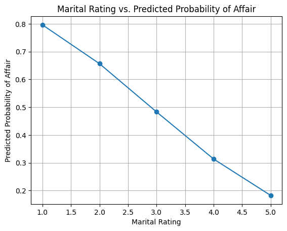

```python
# Viz
plt.plot(artificial_data['rate_marriage'], artificial_data['pred_prob'], marker='o')
plt.xlabel('Marital Rating')
plt.ylabel('Predicted Probability of Affair')
plt.title('Marital Rating vs. Predicted Probability of Affair' )

plt.grid(True)
plt.show()
```

- The marital rating shows 1 which is the lowest and 5 being the highest and representing happiness. The line seems to have a negative slope showing that mariage reduces the probablilty of affairs. The one aspect to consider is that the data is very limited and may not be as reliable as we think considering the availability of the data.

(g) Reflect on your analysis in this problem. After completing all the parts of this analysis what remaining and additional ethical and privacy conerns do you have?

- The data seems like very personal information but it also does not seem accurate. The data was also collected a long time ago and there would be different protocols involved now, ezpecially considering consent and privacy.
- I believe that back in the day, there were also norms related to marriage. There were differet perspectives about marriage, when it came to gender roles and affairs. The education column could have a different represenation that what is understood of it now. Also, there are many aspects that are involved and the idea of human behavior seems oversimplified.

### Problem 2

Points: 20

In this problem set, we will use some data from a sports context. The data is provided as part of the [Introduction to Statistial Learning with Applications in Python](https://www.statlearning.com/) textbook. It was taken from the StatLib library which is maintained at Carnegie Mellon University. The data provided is part of the data that was used in the 1988 ASA Graphics Section Poster Session. The salary data were originally from Sports Illustrated, April 20, 1987. The 1986 and career statistics were obtained from The 1987 Baseball Encyclopedia Update published by Collier Books, Macmillan Publishing Company, New York.

Following the directions below to load this data, `Hitters` directly from the `ISLP` python package. You may need to install the `ISLP` package before you can get started. In the Jupyter Hub you can open a terminal and use `pip install ISLP`. Next load the data as follows:

```python
from ISLP import load_data
Hitters = load_data('Hitters')

Hitters.head()
```

|  | AtBat | Hits | HmRun | Runs | RBI | Walks | Years | CAtBat | CHits | CHmRun | CRuns | CRBI | CWalks | League | Division | PutOuts | Assists | Errors | Salary | NewLeague |
| --- | --- | --- | --- | --- | --- | --- | --- | --- | --- | --- | --- | --- | --- | --- | --- | --- | --- | --- | --- | --- |
| 0 | 293 | 66 | 1 | 30 | 29 | 14 | 1 | 293 | 66 | 1 | 30 | 29 | 14 | A | E | 446 | 33 | 20 | NaN | A |
| 1 | 315 | 81 | 7 | 24 | 38 | 39 | 14 | 3449 | 835 | 69 | 321 | 414 | 375 | N | W | 632 | 43 | 10 | 475.0 | N |
| 2 | 479 | 130 | 18 | 66 | 72 | 76 | 3 | 1624 | 457 | 63 | 224 | 266 | 263 | A | W | 880 | 82 | 14 | 480.0 | A |
| 3 | 496 | 141 | 20 | 65 | 78 | 37 | 11 | 5628 | 1575 | 225 | 828 | 838 | 354 | N | E | 200 | 11 | 3 | 500.0 | N |
| 4 | 321 | 87 | 10 | 39 | 42 | 30 | 2 | 396 | 101 | 12 | 48 | 46 | 33 | N | E | 805 | 40 | 4 | 91.5 | N |

(a) Develop your own question to address in this analysis. Your question should be specific and measurable, and it should be able to be addressed through a basic analysis of the `Hitters` dataset. Hint: you will need to get to know this dataset and the variables available to formulate an appropriate question.

- How do a player's hits and home runs affect their salary?

```python
Hitters.info()
```

```
<class 'pandas.core.frame.DataFrame'>
RangeIndex: 322 entries, 0 to 321
Data columns (total 20 columns):
 #   Column     Non-Null Count  Dtype
---  ------     --------------  -----
 0   AtBat      322 non-null    int64
 1   Hits       322 non-null    int64
 2   HmRun      322 non-null    int64
 3   Runs       322 non-null    int64
 4   RBI        322 non-null    int64
 5   Walks      322 non-null    int64
 6   Years      322 non-null    int64
 7   CAtBat     322 non-null    int64
 8   CHits      322 non-null    int64
 9   CHmRun     322 non-null    int64
 10  CRuns      322 non-null    int64
 11  CRBI       322 non-null    int64
 12  CWalks     322 non-null    int64
 13  League     322 non-null    category
 14  Division   322 non-null    category
 15  PutOuts    322 non-null    int64
 16  Assists    322 non-null    int64
 17  Errors     322 non-null    int64
 18  Salary     263 non-null    float64
 19  NewLeague  322 non-null    category
dtypes: category(3), float64(1), int64(16)
memory usage: 44.2 KB
```

(b) Briefly summarize the dataset, describing what data exists and its basic properties. Comment on any issues that need to be resolved before you can proceed with your analysis.

```python
Hitters.describe()
```

|  | AtBat | Hits | HmRun | Runs | RBI | Walks | Years | CAtBat | CHits | CHmRun | CRuns | CRBI | CWalks | PutOuts | Assists | Errors | Salary |
| --- | --- | --- | --- | --- | --- | --- | --- | --- | --- | --- | --- | --- | --- | --- | --- | --- | --- |
| count | 322.000000 | 322.000000 | 322.000000 | 322.000000 | 322.000000 | 322.000000 | 322.000000 | 322.00000 | 322.000000 | 322.000000 | 322.000000 | 322.000000 | 322.000000 | 322.000000 | 322.000000 | 322.000000 | 263.000000 |
| mean | 380.928571 | 101.024845 | 10.770186 | 50.909938 | 48.027950 | 38.742236 | 7.444099 | 2648.68323 | 717.571429 | 69.490683 | 358.795031 | 330.118012 | 260.239130 | 288.937888 | 106.913043 | 8.040373 | 535.925882 |
| std | 153.404981 | 46.454741 | 8.709037 | 26.024095 | 26.166895 | 21.639327 | 4.926087 | 2324.20587 | 654.472627 | 86.266061 | 334.105886 | 333.219617 | 267.058085 | 280.704614 | 136.854876 | 6.368359 | 451.118681 |
| min | 16.000000 | 1.000000 | 0.000000 | 0.000000 | 0.000000 | 0.000000 | 1.000000 | 19.00000 | 4.000000 | 0.000000 | 1.000000 | 0.000000 | 0.000000 | 0.000000 | 0.000000 | 0.000000 | 67.500000 |
| 25% | 255.250000 | 64.000000 | 4.000000 | 30.250000 | 28.000000 | 22.000000 | 4.000000 | 816.75000 | 209.000000 | 14.000000 | 100.250000 | 88.750000 | 67.250000 | 109.250000 | 7.000000 | 3.000000 | 190.000000 |
| 50% | 379.500000 | 96.000000 | 8.000000 | 48.000000 | 44.000000 | 35.000000 | 6.000000 | 1928.00000 | 508.000000 | 37.500000 | 247.000000 | 220.500000 | 170.500000 | 212.000000 | 39.500000 | 6.000000 | 425.000000 |
| 75% | 512.000000 | 137.000000 | 16.000000 | 69.000000 | 64.750000 | 53.000000 | 11.000000 | 3924.25000 | 1059.250000 | 90.000000 | 526.250000 | 426.250000 | 339.250000 | 325.000000 | 166.000000 | 11.000000 | 750.000000 |
| max | 687.000000 | 238.000000 | 40.000000 | 130.000000 | 121.000000 | 105.000000 | 24.000000 | 14053.00000 | 4256.000000 | 548.000000 | 2165.000000 | 1659.000000 | 1566.000000 | 1378.000000 | 492.000000 | 32.000000 | 2460.000000 |

- There seems to be 322 observations, with 20 variables. The data shows baseball player infomration. The salary data comes fron 1987 and ranges between $67 to $2460. There are many data types, but majority includes int64 and there are three categories and one float64.

(c) Use the dataset to provide empirical evidence that addressed your question from (a). Discuss your results. Provide at least two visualizations to support your story.

```python
Hitters_clean = Hitters.dropna(subset=['Salary'])
Hitters_clean.head()
```

|  | AtBat | Hits | HmRun | Runs | RBI | Walks | Years | CAtBat | CHits | CHmRun | CRuns | CRBI | CWalks | League | Division | PutOuts | Assists | Errors | Salary | NewLeague |
| --- | --- | --- | --- | --- | --- | --- | --- | --- | --- | --- | --- | --- | --- | --- | --- | --- | --- | --- | --- | --- |
| 1 | 315 | 81 | 7 | 24 | 38 | 39 | 14 | 3449 | 835 | 69 | 321 | 414 | 375 | N | W | 632 | 43 | 10 | 475.0 | N |
| 2 | 479 | 130 | 18 | 66 | 72 | 76 | 3 | 1624 | 457 | 63 | 224 | 266 | 263 | A | W | 880 | 82 | 14 | 480.0 | A |
| 3 | 496 | 141 | 20 | 65 | 78 | 37 | 11 | 5628 | 1575 | 225 | 828 | 838 | 354 | N | E | 200 | 11 | 3 | 500.0 | N |
| 4 | 321 | 87 | 10 | 39 | 42 | 30 | 2 | 396 | 101 | 12 | 48 | 46 | 33 | N | E | 805 | 40 | 4 | 91.5 | N |
| 5 | 594 | 169 | 4 | 74 | 51 | 35 | 11 | 4408 | 1133 | 19 | 501 | 336 | 194 | A | W | 282 | 421 | 25 | 750.0 | A |

```python
Hitters_clean.info()
Hitters_clean.describe()
```

```
<class 'pandas.core.frame.DataFrame'>
Index: 263 entries, 1 to 321
Data columns (total 20 columns):
 #   Column     Non-Null Count  Dtype
---  ------     --------------  -----
 0   AtBat      263 non-null    int64
 1   Hits       263 non-null    int64
 2   HmRun      263 non-null    int64
 3   Runs       263 non-null    int64
 4   RBI        263 non-null    int64
 5   Walks      263 non-null    int64
 6   Years      263 non-null    int64
 7   CAtBat     263 non-null    int64
 8   CHits      263 non-null    int64
 9   CHmRun     263 non-null    int64
 10  CRuns      263 non-null    int64
 11  CRBI       263 non-null    int64
 12  CWalks     263 non-null    int64
 13  League     263 non-null    category
 14  Division   263 non-null    category
 15  PutOuts    263 non-null    int64
 16  Assists    263 non-null    int64
 17  Errors     263 non-null    int64
 18  Salary     263 non-null    float64
 19  NewLeague  263 non-null    category
dtypes: category(3), float64(1), int64(16)
memory usage: 38.1 KB
```

|  | AtBat | Hits | HmRun | Runs | RBI | Walks | Years | CAtBat | CHits | CHmRun | CRuns | CRBI | CWalks | PutOuts | Assists | Errors | Salary |
| --- | --- | --- | --- | --- | --- | --- | --- | --- | --- | --- | --- | --- | --- | --- | --- | --- | --- |
| count | 263.000000 | 263.000000 | 263.000000 | 263.000000 | 263.000000 | 263.000000 | 263.000000 | 263.000000 | 263.000000 | 263.000000 | 263.000000 | 263.000000 | 263.000000 | 263.000000 | 263.000000 | 263.000000 | 263.000000 |
| mean | 403.642586 | 107.828897 | 11.619772 | 54.745247 | 51.486692 | 41.114068 | 7.311787 | 2657.543726 | 722.186312 | 69.239544 | 361.220532 | 330.418251 | 260.266160 | 290.711027 | 118.760456 | 8.593156 | 535.925882 |
| std | 147.307209 | 45.125326 | 8.757108 | 25.539816 | 25.882714 | 21.718056 | 4.793616 | 2286.582929 | 648.199644 | 82.197581 | 331.198571 | 323.367668 | 264.055868 | 279.934575 | 145.080577 | 6.606574 | 451.118681 |
| min | 19.000000 | 1.000000 | 0.000000 | 0.000000 | 0.000000 | 0.000000 | 1.000000 | 19.000000 | 4.000000 | 0.000000 | 2.000000 | 3.000000 | 1.000000 | 0.000000 | 0.000000 | 0.000000 | 67.500000 |
| 25% | 282.500000 | 71.500000 | 5.000000 | 33.500000 | 30.000000 | 23.000000 | 4.000000 | 842.500000 | 212.000000 | 15.000000 | 105.500000 | 95.000000 | 71.000000 | 113.500000 | 8.000000 | 3.000000 | 190.000000 |
| 50% | 413.000000 | 103.000000 | 9.000000 | 52.000000 | 47.000000 | 37.000000 | 6.000000 | 1931.000000 | 516.000000 | 40.000000 | 250.000000 | 230.000000 | 174.000000 | 224.000000 | 45.000000 | 7.000000 | 425.000000 |
| 75% | 526.000000 | 141.500000 | 18.000000 | 73.000000 | 71.000000 | 57.000000 | 10.000000 | 3890.500000 | 1054.000000 | 92.500000 | 497.500000 | 424.500000 | 328.500000 | 322.500000 | 192.000000 | 13.000000 | 750.000000 |
| max | 687.000000 | 238.000000 | 40.000000 | 130.000000 | 121.000000 | 105.000000 | 24.000000 | 14053.000000 | 4256.000000 | 548.000000 | 2165.000000 | 1659.000000 | 1566.000000 | 1377.000000 | 492.000000 | 32.000000 | 2460.000000 |

```python
# Regresion Model
X = Hitters_clean[['Hits', 'HmRun']]
y = Hitters_clean['Salary']

# Referenced: Bhamipuri, J. (2025). IMT_573_Lab7_regression.ipynb
X = sm.add_constant(X)
model = sm.OLS(y, X).fit()

print(model.summary())
```

```
                            OLS Regression Results
==============================================================================
Dep. Variable:                 Salary   R-squared:                       0.209
Model:                            OLS   Adj. R-squared:                  0.203
Method:                 Least Squares   F-statistic:                     34.42
Date:                Sun, 30 Nov 2025   Prob (F-statistic):           5.46e-14
Time:                        16:59:52   Log-Likelihood:                -1949.2
No. Observations:                 263   AIC:                             3904.
Df Residuals:                     260   BIC:                             3915.
Df Model:                           2
Covariance Type:            nonrobust
==============================================================================
                 coef    std err          t      P>|t|      [0.025      0.975]
------------------------------------------------------------------------------
const         58.9684     64.445      0.915      0.361     -67.931     185.868
Hits           3.5713      0.650      5.491      0.000       2.291       4.852
HmRun          7.9057      3.352      2.359      0.019       1.306      14.505
==============================================================================
Omnibus:                       92.781   Durbin-Watson:                   1.971
Prob(Omnibus):                  0.000   Jarque-Bera (JB):              311.065
Skew:                           1.504   Prob(JB):                     2.84e-68
Kurtosis:                       7.397   Cond. No.                         305.
==============================================================================

Notes:
[1] Standard Errors assume that the covariance matrix of the errors is correctly specified.
```

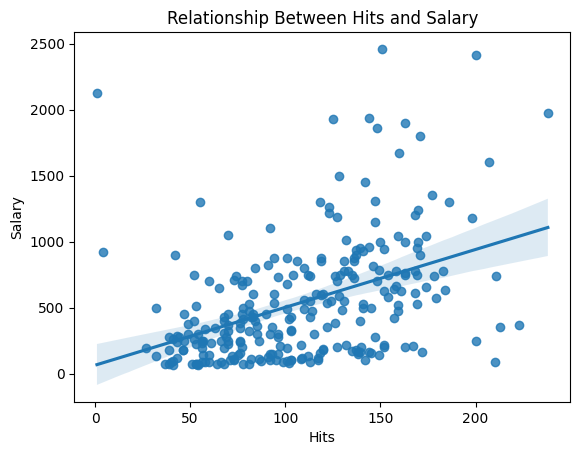

```python
# Viz #1  - Hits vs. Salary
sns.regplot(x = Hitters_clean['Hits'], y = Hitters_clean['Salary'])
plt.title("Relationship Between Hits and Salary")

plt.show()
```

- The slope is positive with certian outliers which can be considered for different player's or circumstances. The more hits than come from a player the higher the salary is, its a gradual rise, considering the number of hits.

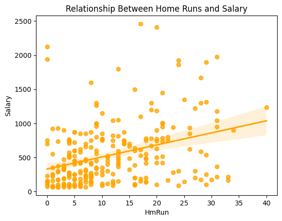

```python
# Viz #2  - Home Runs. vs Salary
sns.regplot(x = Hitters_clean['HmRun'], y = Hitters_clean['Salary'], color='orange')
plt.title("Relationship Between Home Runs and Salary")

plt.show()
```

- The slope is postive and pretty similar to the hits vs salary. This visulaization shows that players still get a salary even if they don't make home runs and it seems home runs do not have the same level of significant effect as the hits vs salary. Though, The more home runs earned results in a stronger effect where home runs start raising the salary.

(d) Comment the questions (and answers) in this analysis. Were you able to answer all of these questions? Are all questions well defined? Is the data good enough to answer all these?

- How do a player's hits and home runs affect their salary?
  - Based on the Regresion model, Hits seem to have a positive and significant effect on salary based on p-value but home runs are also statistcially significant with a large coefficent making it strong.
  - Based on the visualizations, it seems that the more hits results in a higher salary. Even when the home runs are 0, players are still earning more compared to hits. It seems that player's Salary can be affected by the amount of hits they make and less by home runs.
  - It seems both hits and home runs have a positive impact on a player's salary. Homeruns appear to have a slightly stronger effect compared to hits. As indicated by the regression coefficients and the vizualization effect on salary.

```python
# How do a player's hits and home runs affect their salary?

# It seems both hits and home runs have a positive impact on a player's salary.
# Homeruns appear to have a slightly stronger effect compared to hits.
# As indicated by the regression coefficients and the vizualication effect on salary.
```

### Problem 3

Points: 20

In this problem, we will use data available in [Machine Learning with R by Brett Lantz](https://subscription.packtpub.com/search?query=machine%20learning%20r). This data was available in the public domain and a few version exist online.

The data describe individual medical costs billed by health insurance. For each observation, there is information about:

- age: age of primary beneficiary of the insurance policy
- sex: the person's sex, measured here a binary gender
- bmi: body mass index, providing an understanding of body, weights that are relatively high or low relative to height, (kg / m ^ 2)
- children: number of children/dependents covered by health insurance
- smoker: smoking status of the primary beneficiary
- region: the beneficiary's residential area in the US, northeast, southeast, southwest, northwest.
- charges: medical costs billed by health insurance

In our analysis, we will be interested in the relationship between `charges` and the individual characteristics measured.

```python
df = pd.read_csv('insurance.csv')
df.head()
```

|  | age | sex | bmi | children | smoker | region | charges |
| --- | --- | --- | --- | --- | --- | --- | --- |
| 0 | 19 | female | 27.900 | 0 | yes | southwest | 16884.92400 |
| 1 | 18 | male | 33.770 | 1 | no | southeast | 1725.55230 |
| 2 | 28 | male | 33.000 | 3 | no | southeast | 4449.46200 |
| 3 | 33 | male | 22.705 | 0 | no | northwest | 21984.47061 |
| 4 | 32 | male | 28.880 | 0 | no | northwest | 3866.85520 |

```python
df.dtypes
```

```
age           int64
sex          object
bmi         float64
children      int64
smoker       object
region       object
charges     float64
dtype: object
```

In our analysis, we will be interested in the relationship between charges and the individual characteristics measured.

(a) Examine the bivariate relationships present in the data. Briefly discuss notable results.

- There seems to be a bivariate relationship between charges and all the other variables because they impact the insurance information in return affecting the overall cost (charge).
  - Like for example;
    - Charge vs. BMI
    - Charge vs. age/sex
    - Charge vs. smoker

(b) Fit a multiple linear regression model. How much variance in the medical costs(charges) does this variable- bmi explain?

```python
# Referenced: Bhamipuri, J. (2025). IMT_573_ps7_regression.ipynb
# Multiple Linear Regression Model - BMI focus and charges
X = df[['bmi']]
X = sm.add_constant(X)
y = df['charges']

# Referenced: Bhamipuri, J. (2025). IMT_573_ps7_regression.ipynb
model = sm.OLS(y, X).fit()
print(model.summary())
```

```
                            OLS Regression Results
==============================================================================
Dep. Variable:                charges   R-squared:                       0.039
Model:                            OLS   Adj. R-squared:                  0.039
Method:                 Least Squares   F-statistic:                     54.71
Date:                Sun, 30 Nov 2025   Prob (F-statistic):           2.46e-13
Time:                        18:10:39   Log-Likelihood:                -14451.
No. Observations:                1338   AIC:                         2.891e+04
Df Residuals:                    1336   BIC:                         2.892e+04
Df Model:                           1
Covariance Type:            nonrobust
==============================================================================
                 coef    std err          t      P>|t|      [0.025      0.975]
------------------------------------------------------------------------------
const       1192.9372   1664.802      0.717      0.474   -2072.974    4458.849
bmi          393.8730     53.251      7.397      0.000     289.409     498.337
==============================================================================
Omnibus:                      261.030   Durbin-Watson:                   1.983
Prob(Omnibus):                  0.000   Jarque-Bera (JB):              431.091
Skew:                           1.297   Prob(JB):                     2.45e-94
Kurtosis:                       4.004   Cond. No.                         160.
==============================================================================

Notes:
[1] Standard Errors assume that the covariance matrix of the errors is correctly specified.
```

- The BMI seems to explain 0.039 variance, which is based on the R-squared, in charges. The BMI also seems significantly significant basec on p-value and coefficient.

(c) Evaluate the statistical assumptions in your regression analysis from part (b) by performing a basic analysis of model residuals and any unusual observations. Discuss any concerns you have about your model.

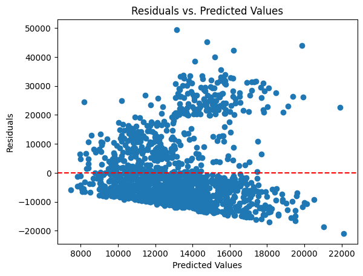

```python
# Basic analysis of model residuals
predict = model.predict(X)
residuals = y - predict

# plot residuals
plt.scatter(predict, residuals)
plt.axhline(y=0, color='r', linestyle='--')
plt.xlabel('Predicted Values')
plt.ylabel('Residuals')
plt.title('Residuals vs. Predicted Values')
plt.show()

# Reference: Bhamipuri, J. (2025). IMT_573_Lab7_regression.ipynb
# Reference: GeeksforGeeks. (2025, July 23). https://www.geeksforgeeks.org/machine-learning/how-to-extract-the-residuals-and-predicted-values-from-linear-model-in-r/
```

- There are many outliers and there is also certain area were data is gathered, representing the relation between predicted and residual values. The outliers could represent out of range BMI values or outside factors impacting the values.

(d) Use a stepwise model selection procedure of your choice to obtain a "best" fit model. Is the model different from the full model you fit in part (b)? If yes, how so?

```python
df.dtypes
```

[output not shown]

```python
df_dummy = pd.get_dummies(df, columns=['region'], drop_first=True)
print(df_dummy.dtypes)
```

[output not shown]

```python
# Change data types of dummy variables to int64
df_dummy['region_northwest'] = df_dummy['region_northwest'].astype('int64')
df_dummy['region_southeast'] = df_dummy['region_southeast'].astype('int64')
df_dummy['region_southwest'] = df_dummy['region_southwest'].astype('int64')
print(df_dummy.dtypes)
```

```
age                   int64
sex                   int64
bmi                 float64
children              int64
smoker                int64
charges             float64
region_northwest      int64
region_southeast      int64
region_southwest      int64
dtype: object
```

```python
# Reference: Bhamipuri, J. (2025). IMT_573_ps8_logistic_regression.ipynb
# Reference: w3schools. (2025). Logistic Regression in Python. https://www.w3schools.com/python/python_ml_logistic_regression.asp
X = df_dummy[['age','sex','bmi','children','smoker','region_northwest','region_southeast','region_southwest']]

X = sm.add_constant(X)
y = df_dummy['charges']

model = sm.OLS(y, X).fit()
print(model.summary())
```

```
                            OLS Regression Results
==============================================================================
Dep. Variable:                charges   R-squared:                       0.751
Model:                            OLS   Adj. R-squared:                  0.749
Method:                 Least Squares   F-statistic:                     500.8
Date:                Sun, 30 Nov 2025   Prob (F-statistic):               0.00
Time:                        22:06:38   Log-Likelihood:                -13548.
No. Observations:                1338   AIC:                         2.711e+04
Df Residuals:                    1329   BIC:                         2.716e+04
Df Model:                           8
Covariance Type:            nonrobust
====================================================================================
                       coef    std err          t      P>|t|      [0.025      0.975]
------------------------------------------------------------------------------------
const            -1.194e+04    987.819    -12.086      0.000   -1.39e+04      -1e+04
age                256.8564     11.899     21.587      0.000     233.514     280.199
sex               -131.3144    332.945     -0.394      0.693    -784.470     521.842
bmi                339.1935     28.599     11.860      0.000     283.088     395.298
children           475.5005    137.804      3.451      0.001     205.163     745.838
smoker            2.385e+04    413.153     57.723      0.000     2.3e+04    2.47e+04
region_northwest  -352.9639    476.276     -0.741      0.459   -1287.298     581.370
region_southeast -1035.0220    478.692     -2.162      0.031   -1974.097     -95.947
region_southwest  -960.0510    477.933     -2.009      0.045   -1897.636     -22.466
==============================================================================
Omnibus:                      300.366   Durbin-Watson:                   2.088
Prob(Omnibus):                  0.000   Jarque-Bera (JB):              718.887
Skew:                           1.211   Prob(JB):                    7.86e-157
Kurtosis:                       5.651   Cond. No.                         311.
==============================================================================

Notes:
[1] Standard Errors assume that the covariance matrix of the errors is correctly specified.
```

- The model looks very different because there are more variables in one compared to the other one. It also seems that the p-value also seems to show that there is limited significance with sex and region_northwest.

EXTRA CREDIT (Max point: 2) : Fit a regression tree using the same covariates in your "best" fit model from part (d). Use cross validation to select the "best" tree. Compare the models from part (d) and (f) based on their performance. Which do you prefer? Be sure to justify your preference.

```python
# Refernce: scikit-learn developers. (n.d.). Decision Tree Regression — plot_tree_regression example. In scikit-learn documentation. Retrieved November 30, 2025, from https://scikit-learn.org/stable/auto_examples/tree/plot_tree_regression.html
# Refernce: 10-dot-7 Demonstration CART. (n.d.). In Course materials for Canvas course 1830727. University of Washington. Retrieved November 30, 2025, from https://canvas.uw.edu/courses/1830727/pages/10-dot-7-demonstration-cart?module_item_id=24478687

from sklearn.tree import DecisionTreeRegressor
from sklearn.model_selection import cross_val_score, GridSearchCV
```

```python
# Refernce: scikit-learn developers. (n.d.). Decision Tree Regression — plot_tree_regression example. In scikit-learn documentation. Retrieved November 30, 2025, from https://scikit-learn.org/stable/auto_examples/tree/plot_tree_regression.html
# Refernce: 10-dot-7 Demonstration CART. (n.d.). In Course materials for Canvas course 1830727. University of Washington. Retrieved November 30, 2025, from https://canvas.uw.edu/courses/1830727/pages/10-dot-7-demonstration-cart?module_item_id=24478687

# Considering regression results for best fit
X = df_dummy[['age','bmi','children','smoker','region_southeast','region_southwest']]
y = df_dummy['charges']

# Regression Tree Model
regression_tree = DecisionTreeRegressor(random_state=0)

# Refernce: Muller, J. (2017, June 21). Using decision tree regression and cross-validation in sklearn [Question & answers]. Stack Overflow. https://stackoverflow.com/questions/44682307/using-decision-tree-regression-and-cross-validation-in-sklearn
# Cross-validation to get best tree
grid = GridSearchCV(regression_tree, {'min_samples_leaf': range(2, 10)}, cv=5)
grid.fit(X, y)
```

```
GridSearchCV(cv=5, estimator=DecisionTreeRegressor(random_state=0),
             param_grid={'min_samples_leaf': range(2, 10)})
```

### Problem 4

Points: 20

The Wisconsin Breast Cancer dataset is available on the [UCI Machine Learning Repository](https://archive.ics.uci.edu/dataset/15/breast+cancer+wisconsin+original). Our goal in this problem will be to predict whether observations (i.e. tumors) are malignant or benign. We will use the original dataset in this problem.

(a) Obtain the data and load it into your programming environment by pulling it directly from the web (links provided below). (Do **not** download it and import it from a CSV file.) Give a brief description of the data.

```python
# Web location of data file
location = "http://archive.ics.uci.edu/ml/machine-learning-databases/"
dataframe = "breast-cancer-wisconsin/breast-cancer-wisconsin.data"
```

(b) Investigate the data, ensuring that each variable is properly named and cast as the correct data type. Discuss any missing data.

```python
# Load data
data = pd.read_csv(location + dataframe, header=None)
```

```python
data.head()
```

|  | 0 | 1 | 2 | 3 | 4 | 5 | 6 | 7 | 8 | 9 | 10 |
| --- | --- | --- | --- | --- | --- | --- | --- | --- | --- | --- | --- |
| 0 | 1000025 | 5 | 1 | 1 | 1 | 2 | 1 | 3 | 1 | 1 | 2 |
| 1 | 1002945 | 5 | 4 | 4 | 5 | 7 | 10 | 3 | 2 | 1 | 2 |
| 2 | 1015425 | 3 | 1 | 1 | 1 | 2 | 2 | 3 | 1 | 1 | 2 |
| 3 | 1016277 | 6 | 8 | 8 | 1 | 3 | 4 | 3 | 7 | 1 | 2 |
| 4 | 1017023 | 4 | 1 | 1 | 3 | 2 | 1 | 3 | 1 | 1 | 2 |

```python
# Got the column names from the dataset website
columns = ["Sample_code_number", "Clump_Thickness", "Uniformity_Cell_Size",
    "Uniformity_Cell_Shape", "Marginal_Adhesion", "Single_Epithelial_Cell_Size",
    "Bare_Nuclei", "Bland_Chromatin", "Normal_Nucleoli", "Mitoses", "Class"]

data.columns = columns
data.head()
```

|  | Sample_code_number | Clump_Thickness | Uniformity_Cell_Size | Uniformity_Cell_Shape | Marginal_Adhesion | Single_Epithelial_Cell_Size | Bare_Nuclei | Bland_Chromatin | Normal_Nucleoli | Mitoses | Class |
| --- | --- | --- | --- | --- | --- | --- | --- | --- | --- | --- | --- |
| 0 | 1000025 | 5 | 1 | 1 | 1 | 2 | 1 | 3 | 1 | 1 | 2 |
| 1 | 1002945 | 5 | 4 | 4 | 5 | 7 | 10 | 3 | 2 | 1 | 2 |
| 2 | 1015425 | 3 | 1 | 1 | 1 | 2 | 2 | 3 | 1 | 1 | 2 |
| 3 | 1016277 | 6 | 8 | 8 | 1 | 3 | 4 | 3 | 7 | 1 | 2 |
| 4 | 1017023 | 4 | 1 | 1 | 3 | 2 | 1 | 3 | 1 | 1 | 2 |

```python
data.dtypes
```

```
Sample_code_number              int64
Clump_Thickness                 int64
Uniformity_Cell_Size            int64
Uniformity_Cell_Shape           int64
Marginal_Adhesion               int64
Single_Epithelial_Cell_Size     int64
Bare_Nuclei                    object
Bland_Chromatin                 int64
Normal_Nucleoli                 int64
Mitoses                         int64
Class                           int64
dtype: object
```

(c) Split the data into a training and test set such that a random 70% of the observations are in the training set.

```python
# Referenced: hernamesbarbara. (2013, April 21). Change column type in pandas [Question & answers]. Stack Overflow. https://stackoverflow.com/questions/15891038/change-column-type-in-pandas
# Convert data types to ones mathcing on website
data['Bare_Nuclei'] = pd.to_numeric(data['Bare_Nuclei'], errors='coerce')
data['Sample_code_number'] = data['Sample_code_number'].astype('category')
data.dtypes
```

```
Sample_code_number             category
Clump_Thickness                   int64
Uniformity_Cell_Size              int64
Uniformity_Cell_Shape             int64
Marginal_Adhesion                 int64
Single_Epithelial_Cell_Size       int64
Bare_Nuclei                     float64
Bland_Chromatin                   int64
Normal_Nucleoli                   int64
Mitoses                           int64
Class                             int64
dtype: object
```

(d) Fit a ML model to predict whether tissue samples are malignant or benign. Then use your model to classify cases in your test set, which is the remaining 30% of the all the observations. Compute and discuss the resulting confusion matrix. Be sure to address which of the errors that are identified you consider most problematic in this context.

```python
# Based on website --> Class: (2 for benign, 4 for malignant)
data['Class'] = data['Class'].map({2: 0, 4: 1})  # 0 for benign, 1 for malignant
data.head()
```

|  | Sample_code_number | Clump_Thickness | Uniformity_Cell_Size | Uniformity_Cell_Shape | Marginal_Adhesion | Single_Epithelial_Cell_Size | Bare_Nuclei | Bland_Chromatin | Normal_Nucleoli | Mitoses | Class |
| --- | --- | --- | --- | --- | --- | --- | --- | --- | --- | --- | --- |
| 0 | 1000025 | 5 | 1 | 1 | 1 | 2 | 1.0 | 3 | 1 | 1 | 0 |
| 1 | 1002945 | 5 | 4 | 4 | 5 | 7 | 10.0 | 3 | 2 | 1 | 0 |
| 2 | 1015425 | 3 | 1 | 1 | 1 | 2 | 2.0 | 3 | 1 | 1 | 0 |
| 3 | 1016277 | 6 | 8 | 8 | 1 | 3 | 4.0 | 3 | 7 | 1 | 0 |
| 4 | 1017023 | 4 | 1 | 1 | 3 | 2 | 1.0 | 3 | 1 | 1 | 0 |

```python
data = data.dropna()
```

```python
# Referenced: Bhamipuri, J. (2025). IMT_573_Lab8_logistic_regression.ipynb
from sklearn.model_selection import train_test_split
from sklearn.linear_model import LogisticRegression
from sklearn.ensemble import RandomForestClassifier
from sklearn.metrics import confusion_matrix, ConfusionMatrixDisplay, classification_report
```

```python
# Refernce: W3Schools.com. (2025). Machine Learning – Train/Test. https://www.w3schools.com/python/python_ml_train_test.asp
# Referenced: Bhamipuri, J. (2025). IMT_573_Lab8_logistic_regression.ipynb
X = data.drop(columns=['Sample_code_number','Class'])
y = data['Class']

# Split into train and test sets - testing 30%
X_train, X_test, y_train, y_test = train_test_split(X, y, test_size=0.3, random_state=16)

model = LogisticRegression(max_iter=1000)
model.fit(X_train, y_train)

y_pred = model.predict(X_test)
# Refernce: W3Schools.com. (2025). Machine Learning – Train/Test. https://www.w3schools.com/python/python_ml_train_test.asp
# Confusion matrix idea - not actual plot
conf_matrix = confusion_matrix(y_test, y_pred)
print(conf_matrix)
print(classification_report(y_test, y_pred))
```

```
[[133   6]
 [  2  64]]
              precision    recall  f1-score   support

           0       0.99      0.96      0.97       139
           1       0.91      0.97      0.94        66

    accuracy                           0.96       205
   macro avg       0.95      0.96      0.96       205
weighted avg       0.96      0.96      0.96       205
```

### Problem 5

Points: 10

Please answer the questions below by writing a short response.

(a) Describe three real-life applications in which **classification** might be useful. Describe the response, as well as the predictors. Is the goal in each application inference or predictions? Explain your answer.

- When considering medical reports, like for example a Covid Test. The response would be Covid positive or Covid negative. I think predictors could be like symptoms, location, age, immune system, and test results. The goal in this application seems to be inference, because there is a need to understand prioroty.
- When passing or failing a class, expecially through transcript. The response would be pass or fail but also they can be categorized by number that also put them into the classification of pass or fail. The predictors would involve homework, involvement, course work, attendance, exams/quizzes. The goal in this application could very likely be prediction to help get an understanding of what the grade is likely going to be and working towards that but recognizes the needs.
- When considering a loan, there are many aspects involved but through abank you would need to apply and get approved or denied. The predictors would include income, credit, other debt, job information of the person who applied for the loan. The goal in this application seems to be prediction as well, because it matter of trying and the control to make the choices for getting it working toward it is not in your hand, the preperation through documents could help but would still rely in prediction.

b) Describe three real-life applications in which **regression** might be useful. Describe the response, as well as the predictors. Is the goal in each application inference or predictions? Explain your answer.

- When considering black friday and the sales forecasts from a customer point of view, the response would be the sales amount. The predictors would be the season, the marketing, the need, the creation of want, the store reputation. The goal in this application as a customer would be inference, your choice and based on what you need there would be more control in the customers hand where as the employees and involved staff would focus on prediction to get an idea of the overall sales made,
- When working towards a goal, like measuring the affects of working out. The response would be weight, strength, and endurance changes. The predictors would include the work put in during workout time, the food, protein, age, sleep, hydration. The goal for this application would very likely be inference because the control is in your hands and your taking the steps.
- When considring house prices, especially with changing times the price of houses need to be monitored if you want to grab a chance at a good deal. The predictions would involve location, rooms, bathrooms, size, nearby grocery marts, driving or walking location, and weather. The goal for this application would probably be predictions because you would be making guesses before the finalized price.

(c) What are the advantages and disadvantages of a very flexible (versus a less flexible) approach for regression or classification? Under what circumstances might a more flexible approach be preferred to a less flexible approach? When might a less flexible approach be preferred?

- I think flexible regression would be able to handle super complex relationship but can be hard to explain. Less flexible regression might be easier to understand and has a strutured outline. I think flexible classification can also be hard to understand but can be very accurate. Less flexible classification includes more predicatble factors and is likely more simple.
- An advantage of a flexible model would be that there is more involved and it can handle more accurate and complex aspects, whereas the disadvantages include having a super full plate and having to deal with too much and also having a harder time understanding.
- I think a less flexibe approach might be preferred when there is a lot of information that includes creatvity and is diverse in many ways.

### Problem 6

Points: 10

Suppose we have a dataset with five predictors, $X_1 =$ GPA, $X_2 =$ IQ, $X_3 =$ Gender (1 for Female, and 0 for Male), $X_4 =$ Interaction between GPA and IQ, and $X_5 =$ Interaction between GPA and Gender. Note: the data here is limited as gender was collected as a binary variable.

The response is starting salary after graduation (in thousands of dollars). Suppose we use least squares to fit the model and get $\hat{\beta}_0=50, \hat{\beta}_1=20, \hat{\beta}_2=0.07, \hat{\beta}_3=35, \hat{\beta}_4=0.01$, and $\hat{\beta}_5=-10$.

(a) Which answer is correct and why? [single choice question]

i. For a fixed value of IQ and GPA, males earn more on average than females.

ii. For a fixed value of IQ and GPA, females earn more on average than males.

iii. For a fixed value of IQ and GPA, males earn more on average than females provided that the GPA is high enough.

iv. For a fixed value of IQ and GPA, females earn more on average than males provided that the GPA is high enough.

- I think the correct answer is:
  - iii. For a fixed value of IQ and GPA, males earn more on average than females provided that the GPA is high enough.
- Because when considering female vs male, it seems females earn more when they have a lower GPA and males earn more when thay have a higher GPA.

Notes;

- (B0 + B1X1 + B2X2 + B3X3 + B4(X1X2) + B5(X1X3))^2
- Female = 50 + 20(x1) + 0.07(x2) + 35(1) + 0.01(x1 * x2) - 10(X1*1)
  - 35 - 10(GPA*1) = 35-10-10GPA = 25-10GPA
- Male = 50 + 20(X1) + 0.07(X2) + 35(0) + 0.01(X1 * X2) - 10(X1*0)
  - 0 - 10(X1*0) = 0 - 0 - 10GPA = 10GPA

(b) Wite down the least square function and then predict the salary of a female with IQ of 110 and a GPA of 4.0.

- Least square function => Y = (B0 + B1X1 + B2X2 + B3X3 + B4(X1X2) + B5(X1X3))^2
- X1 = 4.0, X2 = 110, X3 = 1
- Y = 50 + 20(4.0) + 0.07(110) + 35(1) + 0.01(4.0 * 110) - 10(4.0*1)
- Y = 50 + 80 + 7.7 + 35 + 4.4 - 40
- Y = 137.1
- Reference: University of Washington. (n.d.). 10.4 The bias‑variance tradeoff. In Course materials for [Course ID 1830727]. Retrieved November 30, 2025, from https://canvas.uw.edu/courses/1830727/pages/10-dot-4-the-bias-variance-tradeoff?module_item_id=24478684

(c) True or false: Since the coefficient for the GPA/IQ interaction term is very small, there is little evidence of an interaction effect. Justify your answer.

- False, because the coefficient looks small but the interaction can still matter when GPA and IQ are large.

### Problem 7 - Extra Credit

Points: Max. 4

Suppose that $X_1, \ldots X_n$ form a random sample from a Poisson distribution for which the mean $\theta$ is unknown, $(\theta>0)$.

(a) Determine the MLE of $\theta$, assuming that at least one of the observed values is different from 0. Show your work.

```python
# Reference: Mehra, V. (n.d.). Introduction to maximum likelihood estimation (MLE). DataCamp. https://www.datacamp.com/tutorial/maximum-likelihood-estimation-mle

# Random sample - testing w/one 0
X = np.array([5, 2, 3, 1, 4, 1, 2, 1, 0])

X_theta = X.mean()
print(X_theta)
```

```
2.111111111111111
```

```python
# Random sample - multiple 0's
x = np.array([5, 2, 3, 0, 4, 0, 2, 1, 0])

x_theta = x.mean()
print(x_theta)
```

```
1.8888888888888888
```

(b) Show that the MLE of $\theta$ does not exists if every observed value is 0.

```python
# Random sample - all 0'sample
O = np.array([[0, 0, 0, 0, 0, 0, 0, 0, 0]])

O_theta = O.mean()
print(O_theta)
```

```
0.0
```

- Using random sample as an reference and example. The MLE of $\theta$ does not exist if every observed value is 0 because $\theta$ is greater than 0.

### Problem 8 - Extra Credit

Points: Max. 4

In this extra credit problem, you'll build a simple web scraper to collect and process text data. You'll write the code necessary to scrape lyrics for a desired artist. Your code should be structured such that one can easily execute your scraping functions for a given artist. There are three deliverables for this assignment:

1. A set of functions necessary for scraping the lyrics of a specific artist.
2. An example implementation of using your functions.
3. A file of example output from your notebook implementation.

The specific approach that you take to structuring your code is up to you, but the final output .csv data should have the following columns (each row is a song from an artist that you choose):

- Column 1: artist
- Column 2: album
- Column 3: song title
- Column 4: URL of song lyrics
- Column 5: song lyrics (all of the lyrics in one column)
- Column 6: number of words in the song

**Data Scraping:** The actual scraping of data should be supported by separate functions that accomplish these tasks:

1. Given an artist, identify all of their albums, songs, and links to songs.
2. Given a set of song links (from step 1), collect the lyrics to each song and store them in a data frame.

In order to do this, you'll need to understand the structure of your lyrics site. The site you use is up to you, but all of this information should be available on lyrics.com.

**Data Processing:**

Once you've scraped the data, you'll need to do some simple text analysis to generate your columns of interest (feel free to do this as part of step 2 above, the collection of lyrics for each song or as a separate step entirely). Recall you are aiming to count the number of words in each song.

**Example Implementation:**

You should demonstrate the implementation of your data scraping functions with a particular artist. To do this you can simply set an artist, and run your scraping functions. The way in which you choose to structure your functions is up to you, as long as the implementation and documentation is clear. One way in which we'll test this is changing the artist to confirm the flexibility of your implementation.

It may look something like this:

```python
# NOTE THIS CODE WILL NOT RUN
# UNTIL YOU WRITE YOUR WEB SCRAPING FUNCTIONS

# Get songs
artist = 'Adele'
all_songs = get_songs(artist)

# Get lyrics -- internally, you may want to another function in your library, such as get_lyrics()
lyrics = get_all_lyrics(songs)

# Save data -- this function should identify the name of the artist and use it in the .csv file it saves
save_lyrics(lyrics)
```

(a) Write a function to get all the songs of a particular artist.

(b) Write a function to get all the lyrics for a particular song. You may also want to write a function to get all the lyrics for a list of songs.

(c) Choose a particular artist. Get all their songs. Get all the lyrics for their songs. Process the data so that you end up with a nice, tidy data structure as described in the instructions (i.e. the six columns listed above). Write out the data to a CSV file.

(d) Produce one visualization of the data to aids in understanding the distribution of words in songs for a particular artist. Comment on what you find.